# Coursera DSS Machine Learning Course Project

Paul Venuto

January 1, 2018

## Executive Summary

Using devices such as Jawbone Up, Nike FuelBand, and Fitbit it is now possible to collect a large amount of data about personal activity relatively inexpensively. These type of devices are part of the quantified self movement – a group of enthusiasts who take measurements about themselves regularly to improve their health, to find patterns in their behavior, or because they are tech geeks. One thing that people regularly do is quantify how much of a particular activity they do, but they rarely quantify how well they do it. In this project, your goal will be to use data from accelerometers on the belt, forearm, arm, and dumbell of 6 participants. They were asked to perform barbell lifts correctly and incorrectly in 5 different ways.

The goal of this project is to predict the manner in which they did the exercise. This is the “classe” variable in the training set. You may use any of the other variables to predict with. You should create a report describing how you built your model, how you used cross validation, what you think the expected out of sample error is, and why you made the choices you did. You will also use your prediction model to predict 20 different test cases.

## About the Data

The data for this project are available here: Training dataset: “https://d396qusza40orc.cloudfront.net/predmachlearn/pml-training.csv”. Testing dataset: “https://d396qusza40orc.cloudfront.net/predmachlearn/pml-testing.csv” The data for this project come from this source: http://groupware.les.inf.puc-rio.br/har. If you use the document you create for this class for any purpose please cite them as they have been very generous in allowing their data to be used for this kind of assignment.

## Data Processing

### Obtaining and Cleaning the data

```r
knitr::opts_chunk$set(echo = TRUE)
```

```r
#Load required libraries
library(caret)
```

```r
library(rpart)
library(rpart.plot)
library(ggplot2)
library(RColorBrewer)
library(randomForest)
library(knitr)

#setting the seed for reproducible computation
set.seed(12345)

#setting the working directory folder
setwd("~/Documents/Coursera")

# loading both testing and training dataset (considering both files were already downloaded)
trainFile <- "./pml-training.csv"
training <- read.csv(file=trainFile, header=TRUE, sep=",", na.strings=c("NA","#DIV/0!",""))
testFile <- "./pml-testing.csv"
testing <- read.csv(file=testFile, header=TRUE, sep=",", na.strings=c("NA","#DIV/0!",""))

dim(training)
```

```
## [1] 19622   160
```

```r
#Remove near zero values from the dataset
nzvCol <- nearZeroVar(training)
training <- training[,-nzvCol]

#Remove any with NA's or have empty strings, and the one's that are not predictors variables
filterData <- function(idf) {
    idx.keep <- !sapply(idf, function(x) any(is.na(x)))
    idf <- idf[, idx.keep]
    idx.keep <- !sapply(idf, function(x) any(x==""))
    idf <- idf[, idx.keep]

    # Remove the columns that aren't the predictor variables
    col.rm <- c("X", "user_name", "raw_timestamp_part_1", "raw_timestamp_part_2",
                "cvtd_timestamp", "new_window", "num_window")
    idx.rm <- which(colnames(idf) %in% col.rm)
    idf <- idf[, -idx.rm]
    return(idf)
}

training <- filterData(training)
finalTrainingDS <- training
dim(finalTrainingDS)
```

```
## [1] 19622    53
```

```r
#Perform the same cleaning process to the testing dataset as well
nzvCol <- nearZeroVar(testing)
testing <- testing[,-nzvCol]
testing <- filterData(testing)
finalTestingDS <- testing
dim(finalTestingDS)
```

```
## [1] 20 53
```

## Data Partitioning

Now we’ll partition the data into training and vaidation datasets.

```r
inTrain <- createDataPartition(y=finalTrainingDS$classe, p=0.70, list=FALSE)
training <- finalTrainingDS[inTrain, ]
validation <- finalTrainingDS[-inTrain, ]
dim(training); dim(validation)
```

```
## [1] 13737    53
```

```
## [1] 5885   53
```

## Data Modelling

We will fit 3 models for predictive analysis to determine the most accurate algorithm to use for this dataset.

### 1st method: Decision Tree

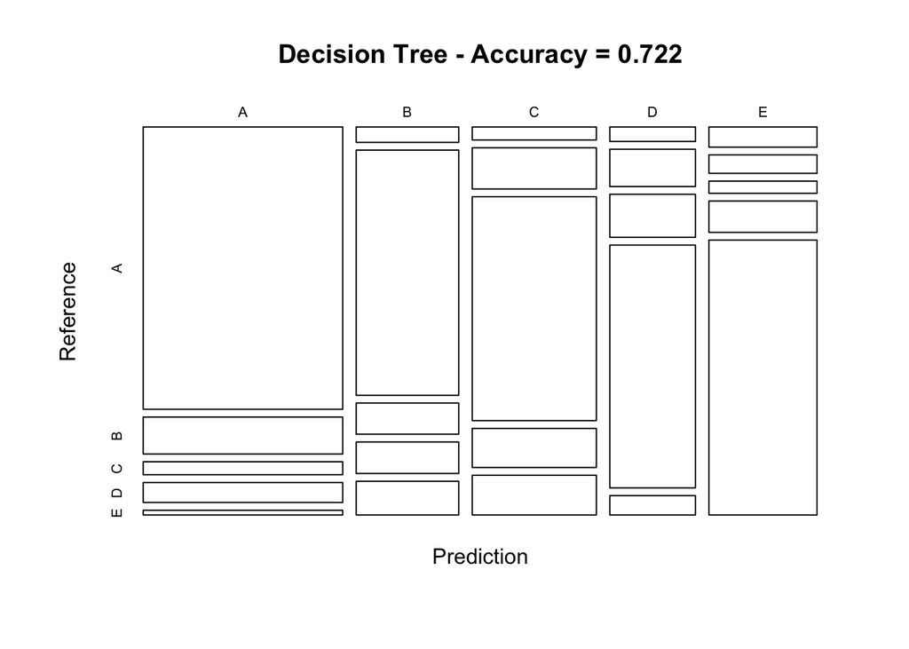

```r
#fit model
modelTree <- rpart(classe~., data=training, method="class")
#predict the model on the validation data set.
predictTree <- predict(modelTree, validation, type = "class")
confMatDecTree <- confusionMatrix(predictTree, validation$classe)
#plot matrix results
plot(confMatDecTree$table, col = confMatDecTree$byClass,
     main = paste("Decision Tree - Accuracy =",
                  round(confMatDecTree$overall['Accuracy'], 4)))
```

### 2nd method: Generalized Boosting

```r
controlGBM <- trainControl(method = "repeatedcv", number = 5, repeats = 1)
modFitGBM  <- train(classe ~ ., data=training, method = "gbm",
                    trControl = controlGBM, verbose = FALSE)
modFitGBM$finalModel
```

```
## A gradient boosted model with multinomial loss function.
## 150 iterations were performed.
## There were 52 predictors of which 42 had non-zero influence.
```

```r
#predict the model on the validation data set.
predictGBM <- predict(modFitGBM, newdata=validation)
confMatGBM <- confusionMatrix(predictGBM, validation$classe)
confMatGBM
```

```
## Confusion Matrix and Statistics
##
##           Reference
## Prediction    A    B    C    D    E
##          A 1648   35    0    3    2
##          B   18 1065   41    4   15
##          C    4   32  968   36    9
##          D    4    6   17  915   23
##          E    0    1    0    6 1033
##
## Overall Statistics
##
##                Accuracy : 0.9565
##                  95% CI : (0.951, 0.9616)
##     No Information Rate : 0.2845
##     P-Value [Acc > NIR] : < 2.2e-16
##
##                   Kappa : 0.945
##  Mcnemar's Test P-Value : 1.651e-07
##
## Statistics by Class:
##
##                      Class: A Class: B Class: C Class: D Class: E
## Sensitivity            0.9845   0.9350   0.9435   0.9492   0.9547
## Specificity            0.9905   0.9836   0.9833   0.9898   0.9985
## Pos Pred Value         0.9763   0.9318   0.9228   0.9482   0.9933
## Neg Pred Value         0.9938   0.9844   0.9880   0.9900   0.9899
## Prevalence             0.2845   0.1935   0.1743   0.1638   0.1839
## Detection Rate         0.2800   0.1810   0.1645   0.1555   0.1755
## Detection Prevalence   0.2868   0.1942   0.1782   0.1640   0.1767
## Balanced Accuracy      0.9875   0.9593   0.9634   0.9695   0.9766
```

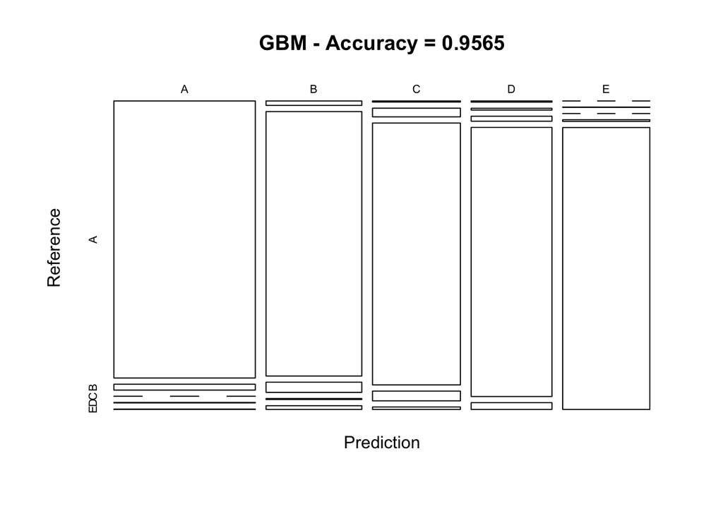

```r
# plot matrix results
plot(confMatGBM$table, col = confMatGBM$byClass,
     main = paste("GBM - Accuracy =", round(confMatGBM$overall['Accuracy'], 4)))
```

### 3rd method: Random Forest

```r
#fit model
modelRF <- train(classe ~ ., data = training, method = "rf", trControl = trainControl(method = "cv", 5), ntree = 250)
modelRF
```

```
## Random Forest
##
## 13737 samples
##    52 predictor
##     5 classes: 'A', 'B', 'C', 'D', 'E'
##
## No pre-processing
## Resampling: Cross-Validated (5 fold)
## Summary of sample sizes: 10990, 10990, 10989, 10990, 10989
## Resampling results across tuning parameters:
##
##   mtry  Accuracy   Kappa
##    2    0.9909005  0.9884884
##   27    0.9899541  0.9872917
##   52    0.9839849  0.9797391
##
## Accuracy was used to select the optimal model using  the largest value.
## The final value used for the model was mtry = 2.
```

```r
#prediction on validation dataset
predictRF <- predict(modelRF, validation)
confMatRF <- confusionMatrix(validation$classe, predictRF)
confMatRF
```

```
## Confusion Matrix and Statistics
##
##           Reference
## Prediction    A    B    C    D    E
##          A 1673    1    0    0    0
##          B   15 1118    6    0    0
##          C    0   15 1008    3    0
##          D    0    0   24  939    1
##          E    0    0    1    4 1077
##
## Overall Statistics
##
##                Accuracy : 0.9881
##                  95% CI : (0.985, 0.9907)
##     No Information Rate : 0.2868
##     P-Value [Acc > NIR] : < 2.2e-16
##
##                   Kappa : 0.9849
##  Mcnemar's Test P-Value : NA
##
## Statistics by Class:
##
##                      Class: A Class: B Class: C Class: D Class: E
## Sensitivity            0.9911   0.9859   0.9702   0.9926   0.9991
## Specificity            0.9998   0.9956   0.9963   0.9949   0.9990
## Pos Pred Value         0.9994   0.9816   0.9825   0.9741   0.9954
## Neg Pred Value         0.9964   0.9966   0.9936   0.9986   0.9998
## Prevalence             0.2868   0.1927   0.1766   0.1607   0.1832
## Detection Rate         0.2843   0.1900   0.1713   0.1596   0.1830
## Detection Prevalence   0.2845   0.1935   0.1743   0.1638   0.1839
## Balanced Accuracy      0.9954   0.9907   0.9832   0.9938   0.9990
```

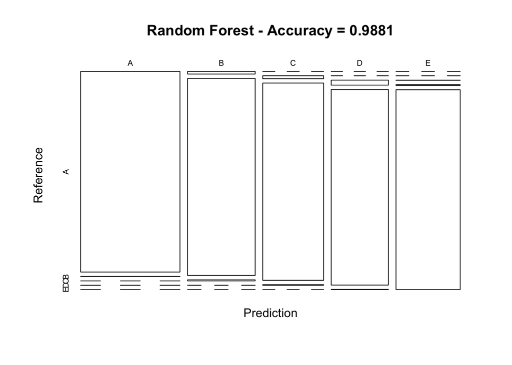

```r
# plot matrix results
plot(confMatRF$table, col = confMatRF$byClass,
     main = paste("Random Forest - Accuracy =",
                  round(confMatRF$overall['Accuracy'], 4)))
```

The accuracy of the 3 regression modeling methods above are:

Random Forest=0.9881; Decision Tree=0.722; GBM=0.9565. Therefore, the Random Forest model will be applied to predict the 20 quiz results (testing dataset) as shown below.

### Predicting The Manner of Exercise for Test Data Set

```r
predict(modelRF, testing[, -length(names(testing))])
```

```
##  [1] B A B A A E D B A A B C B A E E A B B B
## Levels: A B C D E
```